# A Reproducible Science Workflow in RStudio

Egor

April 21, 2018

## Myself

- Bachelor in Computer Science and Biology at McGill
- Fan of open source software
- Started using R in grad school
  - Collaboration with co-supervisor in England
  - No easy way to transmit results
- Discovered RMarkdown this year

[figure not shown]

## Why go reproducible?

- Avoid errors
- Computational reproducibility
- Easy revision

## R Markdown

- Simple formatting syntax for HTML, PDF and MS Word
- Integrate “chunks” of R (or Python) code

## Why have a good workflow?

- Keep a clean workspace and focus on one thing at a time

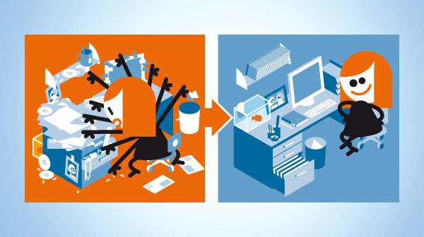

- Make collaboration and sharing work easier

## Basics

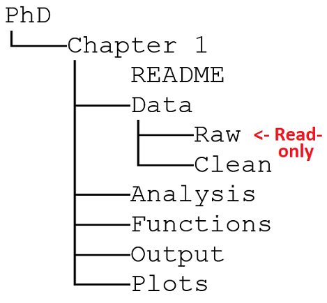

- Keep project in one folder
- Keep raw data folder read-only
- Avoid duplicating code
- Doc folder for notes, text, literature

## Tracking Progress

## Better alternatives

- Informative filenames
- Periodically archiving the whole project (eg: zip)
- Many cloud based serices (also serves as backup)

[figure not shown]

[figure not shown]

[figure not shown]

## Best alternative

- Use software designed for version control
  - Git or SVN
- Alows you to keep track of *key* changes
- Makes you fearless
- Works with GitHub for easy collaboration and cloud backup
- Supported in RStudio

## Git basics

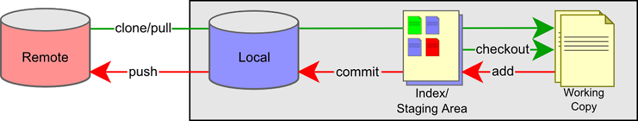

## Resources

- R for Reproducible Scientific Analyses https://swcarpentry.github.io/r-novice-gapminder/
- How to use GitHub with RStudio http://happygitwithr.com/
- Excuse me, do you have a moment to talk about version control? https://dx.doi.org/10.7287%2Fpeerj.preprints.3159v2.
- Guide to RMarkdown https://rmarkdown.rstudio.com/lesson-1.html
- RMarkdown for writing reproducible scientific papers https://libscie.github.io/rmarkdown-workshop/handout.html
- Happy collaboration with Rmd to docx https://rmarkdown.rstudio.com/articles_docx.html
- This presentation: https://github.com/ekatko1/RepSci-CEEB2018